# Service Targets, and the Optimal Policy

Manuel D. Rossetti, PhD P.E.

## Agenda

- The cycle service level and the fill rate, derived, and why “95%” means two things
- The constrained program a target poses, and the cost a target asserts
- The safety factor, and why it is not a normal table
- The exact cost’s shape: convex, and an average of base-stock costs
- What you know before you solve, and an algorithm that needs no search

## Type 1: the Cycle Service Level

Let $\alpha$ represent the probability that a replenishment cycle passes with no stockout.

$$\begin{aligned}
\alpha &= P\{\text{no stockout in a cycle}\}
&&\text{definition}\\
&= P\{D(L) \le r\}
&&\text{by (k), on hand is } r \text{ when } r \text{ is reached}\\
&= G(r), \qquad r = \min\{r : G(r) \ge \alpha\}
&&\text{discrete rule}
\end{aligned}$$

Notice that $Q$ does not appear. Type 1 fixes $r$ by itself, which is why it is the target most often met by hand.

That independence is also its defect. It counts the cycles in which a shortage occurred and says nothing about **how large** it was: a cycle short by one unit and a cycle short by forty count alike. An item ordered in large batches has far fewer cycles in which to fail, and gets the same $r$.

For example, at $\alpha = 0.95$ the transformer needs $G(r) \ge 0.95$: $G(11) = 0.9208$ falls short and $G(12) = 0.9573$ clears it, so $r = 12$.

## Type 2: the Fill Rate

Let $\beta$ represent the fraction of demand filled from the shelf. Each cycle satisfies $Q$ units of demand and falls short by $G^{1}(r)$ units on average:

$$\begin{aligned}
\beta &= \frac{\text{ordered in a cycle} - \text{expected short in a cycle}}
{\text{ordered in a cycle}}
&&\text{units, not occasions}\\
&= \frac{Q - G^{1}(r)}{Q} = 1 - \frac{G^{1}(r)}{Q}
&&\text{shortage per cycle is } G^{1}(r)\\
G^{1}(r) &\le Q(1 - \beta)
&&\text{the condition on } r
\end{aligned}$$

Notice that $Q$ **is** present, and that the measure counts units, which is what an organization that ships to customers cares about. It is the exact ready rate with the far tail $G^{1}(r+Q)$ dropped, so it carries assumption (i) with it.

At $\beta = 0.95$ and $Q = 5$, the transformer needs $G^{1}(r) \le 0.05(5) = 0.25$. $G^{1}(10) = 0.2993$ and $G^{1}(11) = 0.1616$, so $r = 11$.

## The Same Number Means Two Different Things

Both targets were set to 0.95 on the transformer at $Q = 5$, and they differ by a transformer. The policy set to a 95% **cycle service level**: what fill rate does it actually deliver?

| Target | $r$ | Safety stock | Holding cost of it | Exact fill rate | Exact cycle service |
| --- | --- | --- | --- | --- | --- |
| Type 1, $\alpha = 0.95$ | 12 | 4.5 units | $4,275 a year | 0.9838 | 0.9573 |
| Type 2, $\beta = 0.95$ | 11 | 3.5 units | $3,325 a year | 0.9683 | 0.9208 |

The exact columns come from the hand table. At $(12, 5)$ the fill rate is $1 - \tfrac{1}{5}\left[G^{1}(12) - G^{1}(17)\right] = 1 - \tfrac{1}{5}(0.0823 - 0.0013) = 0.9838$, and the cycle service is $G(12) = 0.9573$. The two targets disagree by several points, in both directions, on the same item.

An organization reporting “95% service” without saying which has reported almost nothing. Ask which measure a target refers to before acting on it.

## Solving the Problem the Target Poses

Setting $Q$ to the EOQ and then choosing $r$ is a convenience, not an answer:

$$\min_{r, Q} \; k\frac{\lambda}{Q} + h\left(\frac{Q}{2} + r - \theta\right)
\quad \text{subject to} \quad 1 - \frac{G^{1}(r)}{Q} \ge \beta$$

| $Q$ | $Q(1-\beta)$ | $r$ | Ordering | Holding | Total |
| --- | --- | --- | --- | --- | --- |
| 4 | 0.20 | 11 | $2,475.00 | $5,225.00 | $7,700.00 |
| 5 | 0.25 | 11 | $1,980.00 | $5,700.00 | $7,680.00 |
| 6 | 0.30 | 10 | $1,650.00 | $5,225.00 | **$6,875.00** |
| 7 | 0.35 | 10 | $1,414.29 | $5,700.00 | $7,114.29 |
| 8 | 0.40 | 10 | $1,237.50 | $6,175.00 | $7,412.50 |
| 9 | 0.45 | 10 | $1,100.00 | $6,650.00 | $7,750.00 |
| 10 | 0.50 | 10 | $990.00 | $7,125.00 | $8,115.00 |
| 11 | 0.55 | 9 | $900.00 | $6,650.00 | $7,550.00 |
| 12 | 0.60 | 9 | $825.00 | $7,125.00 | $7,950.00 |

For fixed $Q$ the best $r$ is the smallest feasible one. *Row $Q = 6$:* $G^{1}(r) \le 0.30$ first holds at $r = 10$, where $G^{1}(10) = 0.2993$; ordering is $220(45/6) = \$1{,}650$ and holding is $950(3 + 10 - 7.5) = \$5{,}225$.

Notice that the total is **not unimodal**. It falls to $6,875 at $Q = 6$, rises to $8,115 at $Q = 10$, and falls again at $Q = 11$, where the constraint slackens enough for $r$ to drop a whole unit and save $h$ at a stroke.

The EOQ shortcut gives $(11, 5)$ at $7,680; the program gives $(10, 6)$ at $6,875. **The shortcut costs $805 a year, 10.5%**, at the same target.

## Reading the Target Back into a Cost

A service target does not escape the shortage cost. It asserts a value for it.

**From a solved program.** At the optimum, the approximation’s second condition holds at the $\pi$ that would give the same answer unconstrained:

$$\begin{aligned}
\pi^{*} &= \frac{Q^{*}h}{\lambda\,G^{0}(r^{*})}
= \frac{6(950)}{45(0.1378)}\\
&= \frac{5{,}700}{6.20} = \$919 \text{ per unit short}
\end{aligned}$$

An emergency transformer costs the utility about $5,700. The 95% target implies **less than a sixth of it**. This target holds far too little.

**From a ready rate.** Invert the base-stock critical ratio, $\gamma = b/(b+h)$:

$$b = \frac{\gamma h}{1 - \gamma}$$

| Target $\gamma$ | Implied $b$ |
| --- | --- |
| 0.90 | $8,550 |
| 0.95 | $18,050 |
| 0.98 | $46,550 |
| 0.99 | $94,050 |

Notice the first row: the stated $b = \$8{,}550$ **is** a 90% target.

## Safety Stock and the Safety Factor

Let $z$ represent the **safety factor**, the safety stock in standard deviations of lead time demand:

$$z = \frac{r - \theta}{\sigma_{D(L)}}, \qquad r = \theta + z\,\sigma_{D(L)}$$

$z$ is a change of units. It is comparable across items where $\mathit{ss}$ is not. Looking $z$ up in a table is a **modeling choice**, made silently, and the choice is usually the normal. Do not make it.

| Target | Exact $r$ | Gamma $r$ | Rounds to |
| --- | --- | --- | --- |
| Type 1, $\alpha = 0.90$ | 11 | 11.15 | 11 |
| Type 1, $\alpha = 0.95$ | 12 | 12.50 | 12 |
| Type 1, $\alpha = 0.99$ | 15 | 15.29 | 15 |
| Type 2, $\beta = 0.90$ | 10 | 9.21 | **9** |
| Type 2, $\beta = 0.95$ | 11 | 10.58 | 11 |
| Type 2, $\beta = 0.99$ | 13 | 13.42 | 13 |

Even the gamma, $\alpha = 7.5$, $\beta = 1$, misses once in six, and the miss is a Type 2 target: a quantile asks less of a family than a loss function, which averages over a tail.

One unit is 36.5% of this item’s standard deviation. Solve against the Poisson directly. Use $z$ for **comparing** items, not for **setting** $r$ on a slow mover.

## The Base-Stock Cost Is Convex

Define $\tilde{C}(y) = h(y)^{+} + b(-y)^{+}$, which charges $h$ per unit of positive net inventory and $b$ per unit of negative. Since $\mathit{IN} = S - D(L)$,

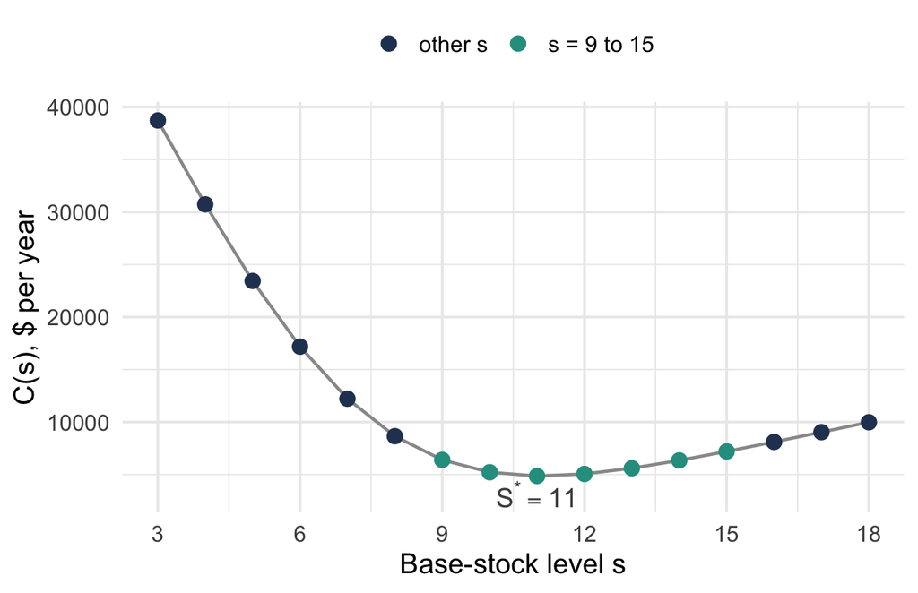

$$C(S) = h\bar{I}(S) + b\bar{B}(S) = E\left[\tilde{C}\big(S - D(L)\big)\right]$$

An expectation of a convex function is convex, so $C(S)$ is convex.

Notice the two ends. For small $S$ the shelf is empty and $C(S)$ falls with slope near $-b$; for large $S$ backorders vanish and it rises with slope near $+h$. In between it turns once, at $S^{*} = 11$.

## The General Cost Is an Average

Recall that $\bar{B}(r,Q)$ and $\bar{I}(r,Q)$ are averages of base-stock quantities over $s = r+1, \ldots, r+Q$:

$$\begin{aligned}
h\bar{I}(r,Q) + b\bar{B}(r,Q)
&= \frac{1}{Q}\sum_{s=r+1}^{r+Q}\Big[h\big(s - \theta + G^{1}(s)\big) + b\,G^{1}(s)\Big]
&&\text{mean of } s \text{ is } r + \tfrac{Q+1}{2}\\
&= \frac{1}{Q}\sum_{s=r+1}^{r+Q} C(s)
&&\text{base-stock cost}\\
C(r, Q) &= \frac{k\lambda + \sum_{s=r+1}^{r+Q} C(s)}{Q}
&&\text{add } k\lambda/Q
\end{aligned}$$

The two-dimensional problem has become a question about **which $Q$ consecutive values of a convex sequence to average**.

*The check.* For the transformer at $(8, 7)$, the seven values from $s = 9$ to $15$ sum to $40,676.04, and

$$C(8, 7) = \frac{9{,}900 + 40{,}676.04}{7} = \$7{,}225.15$$

which is what the four exact formulas give directly. Two routes, one answer, and the second is the one that can be optimized.

## What You Know Before You Solve

Let $w = b/(b+h)$. Two reference quantities, from models you already have:

$$Q_{k} = \sqrt{\frac{2k\lambda}{hw}}, \quad C_{k} = \sqrt{2k\lambda hw}
\quad\text{(deterministic, planned backorders)}, \qquad
C_{\infty} = \sqrt{bh}\,\sigma \quad\text{(base stock)}$$

| Result | Statement | Transformer |
| --- | --- | --- |
| Structure | $r^{*} < S^{*} \le r^{*} + Q^{*}$ | $8 < 11 \le 15$ |
| Cost bounds | $C_{k} \le C^{*} \le \sqrt{C_{k}^{2} + C_{\infty}^{2}}$ | $\$4{,}114.49 \le \$7{,}225.15 \le \$8{,}823.14$ |
| Quantity bounds | $Q_{k} \le Q^{*} \le Q_{k} + C(S^{*})/(hw)$ | $4.81 \le 7 \le 4.81 + 5.68$ |
| Insensitivity | $C^{*}(Q)/C^{*} \le \tfrac{1}{2}\left(Q/Q^{*} + Q^{*}/Q\right)$ | continuous case only |

**The optimal band straddles the optimal base-stock level.** It is the most useful check you can run on a computed answer.

## An Exact Algorithm: the Idea

An $(r, Q)$ policy costs $k\lambda/Q$ plus the average of $Q$ consecutive $C(s)$. For a fixed $Q$, the best $r$ makes those the $Q$ **smallest** values, and by convexity the $Q$ smallest values are consecutive.

Increase $Q$ by one. The window gains exactly one value, and by convexity it is at one end: $C(r)$ just below, or $C(r+Q+1)$ just above. Take the smaller, $c$.

$$\begin{aligned}
QC^{*}(Q) &= k\lambda + \textstyle\sum_{\text{window}} C(s)
&&\text{the cost-average formula}\\
(Q+1)\,C^{*}(Q+1) &= QC^{*}(Q) + c
&&\text{one more value in the window}\\
C^{*}(Q+1) &= C^{*}(Q) - \frac{C^{*}(Q) - c}{Q+1}
&&\text{divide, write } Q = (Q+1) - 1
\end{aligned}$$

The cost falls exactly when the value being added is below the current average. When it is not, no larger $Q$ can help: **stop**.

## The Algorithm

```
optimize(r, Q):

    // Step 0, initialize
    find S*, the smallest S with G(S) >= b/(b+h)
    Q <- 1
    r <- S* - 1
    Cstar <- k*lambda + C(S*)

    // Step 1, the next smallest base-stock cost
    loop:
        c <- min( C(r), C(r+Q+1) )

        // Step 2, test for termination
        if c >= Cstar:
            return r, Q, Cstar

        // Step 3, extend the window
        Q     <- Q + 1
        Cstar <- Cstar - (Cstar - c)/Q
        if C(r) was the smaller:
            r <- r - 1
```

Algorithm Optimize_rq, from Zipkin.

Notice what it does not do: no search over two dimensions, no derivatives, no iteration to convergence. It returns the optimal **integer** policy in at most $Q^{*}$ passes.

The one input is a column of base-stock costs $C(s)$, computed once.

## Optimizing the Transformer

| $s$ | 8 | 9 | 10 | 11 | 12 | 13 | 14 | 15 | 16 |
| --- | --- | --- | --- | --- | --- | --- | --- | --- | --- |
| $C(s)$ | $8,654 | $6,393 | $5,219 | **$4,860** | $5,057 | $5,602 | $6,347 | $7,199 | $8,106 |

| Step | $C(r)$ | $C(r+Q+1)$ | $c$ | Against $C^{*}$ | New $Q$ | New $C^{*}$ | New $r$ |
| --- | --- | --- | --- | --- | --- | --- | --- |
| 0 |  |  |  | $S^{*} = 11$; $C^{*} = 9{,}900 + 4{,}859.83$ | 1 | $14,759.83 | 10 |
| 1 | $5,219 | $5,057 | $5,057.03 | below | 2 | $9,908.43 | 10 |
| 2 | $5,219 | $5,602 | $5,218.57 | below | 3 | $8,345.14 | 9 |
| 3 | $6,393 | $5,602 | $5,601.71 | below | 4 | $7,659.28 | 9 |
| 4 | $6,393 | $6,347 | $6,346.84 | below | 5 | $7,396.80 | 9 |
| 5 | $6,393 | $7,199 | $6,392.69 | below | 6 | $7,229.45 | 8 |
| 6 | $8,654 | $7,199 | $7,199.37 | below | 7 | $7,225.15 | 8 |
| 7 | $8,654 | $8,106 | $8,105.59 | **not below** $7,225.15 |  | stop |  |

## Three Checks, and Two Cautions

*The checks.* All three pass.

- A full enumeration over every $(r, Q)$ returns $(8, 7)$ at $7,225.15.
- $r^{*} < S^{*} \le r^{*} + Q^{*}$: $8 < 11 \le 15$.
- $\$4{,}114.49 \le \$7{,}225.15 \le \$8{,}823.14$.

*Look at the $r$ column.* It runs 10, 10, 9, 9, 9, 8, 8: falling as $Q$ rises, never by more than one per step. A reorder point that jumps by two is a sign the cost column is not convex.

**When the batch is large.** The loop runs once per unit of $Q^{*}$, so an item whose batch is in the hundreds takes hundreds of passes. Start instead near $Q_{k}$, with $r$ near $S^{*} - \beta Q$ for $\beta$ between $1 - w$ and $\tfrac{1}{2}$, and run the same reasoning up or down. It is not a heuristic; it reaches the same optimum from closer.

**When the penalty is on the stockout probability.** With $C(s) = h\bar{I}(s) + b\,\overline{\mathit{SO}}(s)$ the cost need not fall to $S^{*}$ and rise after it. Check the shape of the cost column before trusting any algorithm that assumes it.

## What We Did Today

**Type 1 counts cycles and Type 2 counts units.** At 95% on the transformer they set different reorder points and deliver different service.

**A target is a constrained program,** and its total is not unimodal in $Q$. The EOQ shortcut cost 10.5% at the same target.

**A target asserts a cost.** The 95% fill rate implies $919 per unit short against a real $5,700.

**The safety factor is a change of units.** The table you read it from is a modeling choice; on a slow mover, solve against the count directly.

**The exact cost is an average of a convex sequence,** so the optimum is the $Q$ smallest base-stock costs, found in $Q^{*}$ passes with no search.

## For Next Time

**Read before next session:** *Lumpy Demand*, *The (s, S) Policy* and *Optimality of the (s, S) form*.

Today’s material was *Service Levels Instead of a Shortage Cost*, *The Cost Function and Its Shape*, *What You Know Before You Solve* and *An Exact Algorithm*.

Next session:

- Demand that arrives in lots, and the one measure that changes when it does
- Why an order-up-to rule replaces a fixed quantity, and what undershoot costs
- What the optimality theorem for the $(s, S)$ form does and does not promise

Every model so far assumed demand arrives one unit at a time. Next session drops that.

⌂ Index